# Sequence abundances in community

Chang-Yu Chang

2021-02-16

# Read community sequences

There are two OTU tables and I named them arbitrarily:

1. `communities_abundance`: raw data from Nanxi
2. `communities_abundance_syl`: curated community ESV table from Sylvie

I formated the data.frame so that both of them have the following variables:

- `SampleID`: experiment ID used by Nanxi or Sylvie.
- `Community`: community, for instance, C2R4 or C1Rpool.
- `Transfer`: the transfer when the community was sequenced.
- `Adundance`: the number of this sequence in the community.
- `RelativeAbundance`
- `CommunityESVID`: the sequence identifier. This identifier is community-sequence specific.
- `ESV`: the DNA sequence in 16s V4 region.

In `communities_abundance_syl`, there are other parameters

- `CarbonSource`: the carbon source used for assembly
- `Order`, `Family`, and `Genus`: SILVA assigned taxonomy

```r
communities_abundance
```

[output not shown]

```r
communities_abundance_syl
```

[output not shown]

# Match community ESVs and isolate Sanger sequences

IUPAC notation for DNA base pairs

W, S, M, K, R, Y represent two possiblities for one base pair B, D, H, V represent three possiblitieis N means any nucleotide (but not a gap)

```r
sequences_alignment_syl
```

[output not shown]

# Relative abundance explained by the sequences

Abundances explained by ESVs

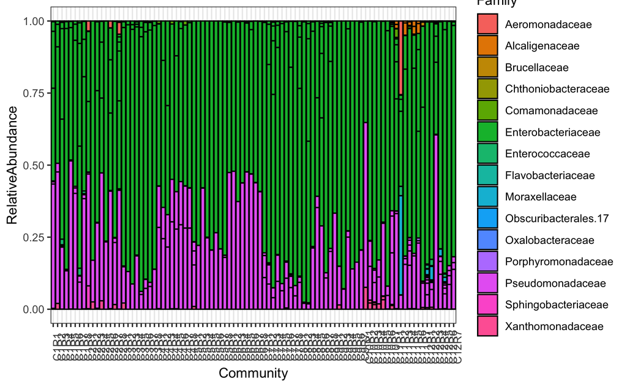

Abundances explained by ESVs in 13 communties

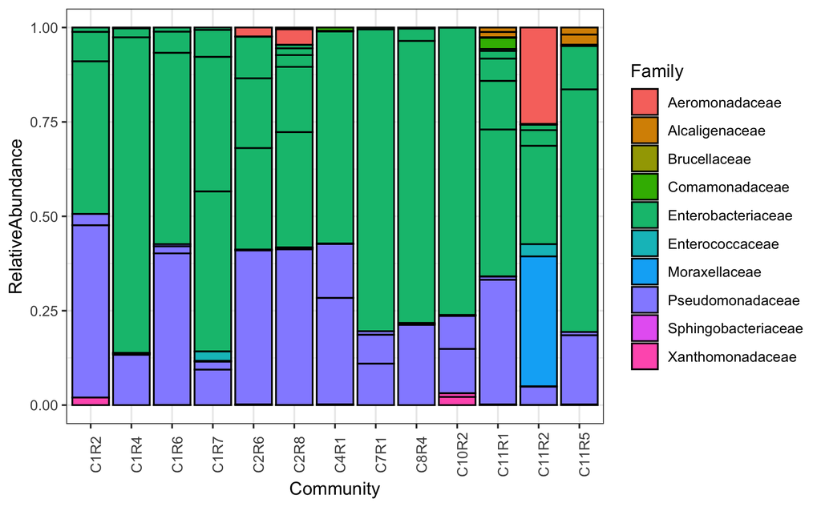

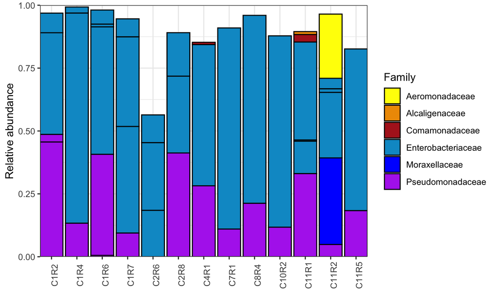

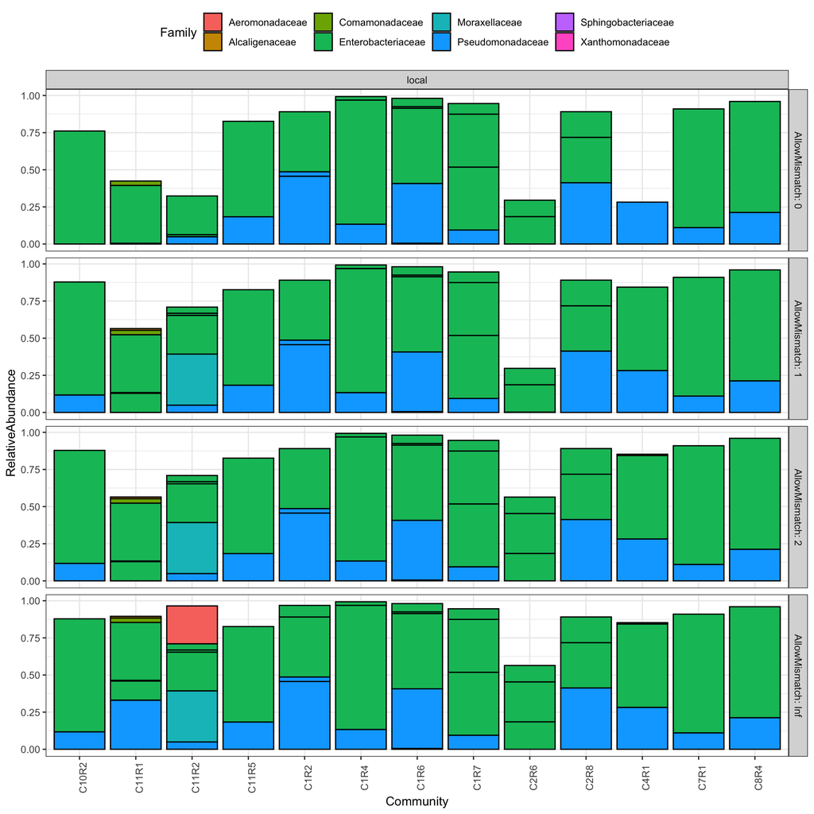